# Titanic Survivor Analysis

Bryan Eng

October 14, 2018

In this assignment, you will gain practical experience with data preprocessing and classification methods. Solve the tasks using R and answer the questions.

## Task 1.

Read in the dataset and split the dataset randomly into 80% training data and 20% test data using the function sample(). To make sure that everybody uses the same training/test split, set the seed of sample to 1 using command set.seed(1).

```r
require(caTools)
require(plyr)
require(tree)
set.seed(1)
```

```r
data <- read.csv('titanic3.csv')
data <- data[-c(1310),]
sample <- sample.split(data, SplitRatio = 0.8)
train <- subset(data, sample == TRUE)
test <- subset(data, sample == FALSE)
```

# Task 2.

Report the number of missing values per attribute in the training and test dataset.

```r
summary(test)
```

```
##      pclass         survived
##  Min.   :1.000   Min.   :0.0000
##  1st Qu.:2.000   1st Qu.:0.0000
##  Median :3.000   Median :0.0000
##  Mean   :2.298   Mean   :0.3759
##  3rd Qu.:3.000   3rd Qu.:1.0000
##  Max.   :3.000   Max.   :1.0000
##
##                                         name         sex
##  Abelseth, Mr. Olaus Jorgensen            :  1         :  0
##  Abrahim, Mrs. Joseph (Sophie Halaut Easu):  1   female:103
##  Adahl, Mr. Mauritz Nils Martin           :  1   male  :179
##  Aldworth, Mr. Charles Augustus           :  1
##  Allison, Mr. Hudson Joshua Creighton     :  1
##  Allum, Mr. Owen George                   :  1
##  (Other)                                  :276
##       age              sibsp            parch            ticket
##  Min.   : 0.3333   Min.   :0.0000   Min.   :0.0000   113503 :  4
##  1st Qu.:21.0000   1st Qu.:0.0000   1st Qu.:0.0000   220845 :  3
##  Median :27.0000   Median :0.0000   Median :0.0000   230136 :  3
##  Mean   :29.5734   Mean   :0.3794   Mean   :0.4184   347088 :  3
##  3rd Qu.:39.0000   3rd Qu.:1.0000   3rd Qu.:0.0000   4133   :  3
##  Max.   :76.0000   Max.   :5.0000   Max.   :9.0000   CA 2144:  3
##  NA's   :63                                          (Other):263
##       fare             cabin     embarked      boat          body
##  Min.   :  0.000          :216    :  0           :177   Min.   :  1.0
##  1st Qu.:  7.896   F4     :  3   C: 67    13     :  9   1st Qu.: 50.0
##  Median : 14.456   B18    :  2   Q: 27    10     :  8   Median :120.0
##  Mean   : 31.122   B45    :  2   S:188    4      :  8   Mean   :124.8
##  3rd Qu.: 29.250   B71    :  2            C      :  8   3rd Qu.:175.0
##  Max.   :263.000   C55 C57:  2            11     :  7   Max.   :322.0
##                    (Other): 55            (Other): 65   NA's   :253
##                               home.dest
##                                    :125
##  New York, NY                      : 17
##  Guntur, India / Benton Harbour, MI:  3
##  Montreal, PQ                      :  3
##  Ottawa, ON                        :  3
##  Philadelphia, PA                  :  3
##  (Other)                           :128
```

```r
summary(train)
```

```
##      pclass         survived                                    name
##  Min.   :1.000   Min.   :0.0000   Connolly, Miss. Kate            :   2
##  1st Qu.:2.000   1st Qu.:0.0000   Kelly, Mr. James                :   2
##  Median :3.000   Median :0.0000   Abbing, Mr. Anthony             :   1
##  Mean   :2.294   Mean   :0.3836   Abbott, Master. Eugene Joseph   :   1
##  3rd Qu.:3.000   3rd Qu.:1.0000   Abbott, Mr. Rossmore Edward     :   1
##  Max.   :3.000   Max.   :1.0000   Abbott, Mrs. Stanton (Rosa Hunt):   1
##                                   (Other)                         :1019
##      sex           age              sibsp            parch
##        :  0   Min.   : 0.1667   Min.   :0.0000   Min.   :0.0000
##  female:363   1st Qu.:21.0000   1st Qu.:0.0000   1st Qu.:0.0000
##  male  :664   Median :28.0000   Median :0.0000   Median :0.0000
##               Mean   :29.9626   Mean   :0.5316   Mean   :0.3759
##               3rd Qu.:39.0000   3rd Qu.:1.0000   3rd Qu.:0.0000
##               Max.   :80.0000   Max.   :8.0000   Max.   :9.0000
##               NA's   :200
##       ticket         fare                     cabin     embarked
##  CA. 2343: 10   Min.   :  0.000                  :798    :  2
##  1601    :  7   1st Qu.:  7.896   B57 B59 B63 B66:  5   C:203
##  3101295 :  7   Median : 14.454   C23 C25 C27    :  5   Q: 96
##  347077  :  7   Mean   : 33.893   G6             :  5   S:726
##  PC 17608:  7   3rd Qu.: 31.387   B96 B98        :  4
##  347082  :  6   Max.   :512.329   C78            :  4
##  (Other) :983   NA's   :1         (Other)        :206
##       boat          body                      home.dest
##         :646   Min.   :  4.0                       :439
##  15     : 31   1st Qu.: 87.0   New York, NY        : 47
##  13     : 30   Median :171.5   London              : 13
##  C      : 30   Mean   :172.2   Cornwall / Akron, OH:  8
##  14     : 27   3rd Qu.:264.5   Montreal, PQ        :  7
##  4      : 23   Max.   :328.0   Paris, France       :  7
##  (Other):240   NA's   :935     (Other)             :506
```

## Task 3.

You can use only past data to predict the future. Assume that you want to predict the survival of a passenger at the time of the accident, i.e. when the Titanic hit the iceberg. With this assumption in mind, which attributes do you use as features?

Passenger class would be an important factor to survival. It is likely that first and second class passengers would be informed of the danger sooner than third class passengers. Because there are so many third class passengers, they may not be told of the danger until it is too late. Third class passengers also have rooms that are much lower down inside the ship, so it would take longer for them to get to the life rafts.

Ticket fare is linked to the passenger class (first class pays more than second and third class, etc). However, data can still be gathered from this attribute.

Age is another important factor. Young adults and very young children are more likely to survive. Young adults are more physically able than other age groups, and are able to make more informed decisions than children. Infants are likely to be carried by their parents, and would be brought along onto the life rafts.

Gender is also an important feature. Women are much more likely to survive, likely due to the mentality that women and children should board the life rafts first.

Sibling count could also predict survivability. Having a larger number of siblings could mean that it is more difficult to gather together, which can lower a passenger’s survivability rate. This can go together with the child/parent feature, as parents are unlikely to leave their children behind.

Finally, the embarked attribute can give some information as well. Passengers that embark from the earlier ports could have rooms that are on higher levels, and thus closer to the life rafts. This could impact their survivability.

## Task 4.

How do you deal with missing values in the different attributes? Report your plan. Preprocess the dataset according to your plan.

Cabin has too many missing values, and with no meaningful way to fill in the blanks the column should be removed. Boat and body are data recorded after the accident, so they should be removed. Name and ticket are just labels that have nothing to do with survival. Finally, home destination is irrelevant to survival.

```r
train <- subset(train, select=-c(name, cabin, ticket, boat, body, home.dest))
test <- subset(test, select=-c(name, cabin, ticket, boat, body, home.dest))
```

There are a few unlabeled entries in the embarked column. The amount is very small in comparison to the dataset, so the rows with the missing embarked data can be removed.

```r
train <- train[train$embarked != "", ]
test <- test[test$embarked != "", ]
```

## Task 5.

Using package tree, learn a decision tree from the training data. Plot the resulting tree. What is the size of the tree? What is the accuracy of the tree on the test dataset?

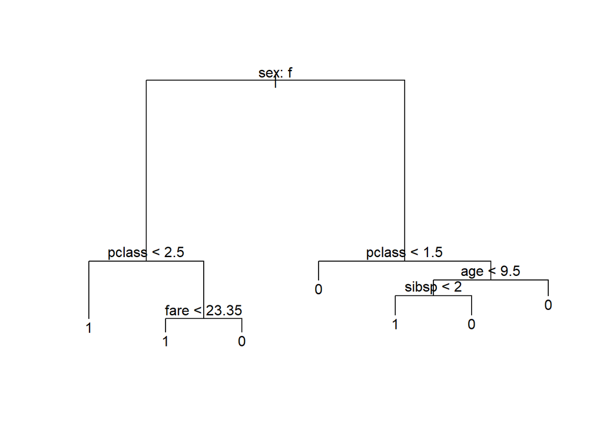

```r
tree.data <- tree(as.factor(survived) ~ pclass + sex + age + fare + sibsp + parch + embarked, data=train)
tree.data2 <- tree(survived ~ pclass + sex + age + fare + sibsp + parch + embarked, data=train)
plot(tree.data, main = "Titanic Decision Tree")
text(tree.data, pretty = 1)
```

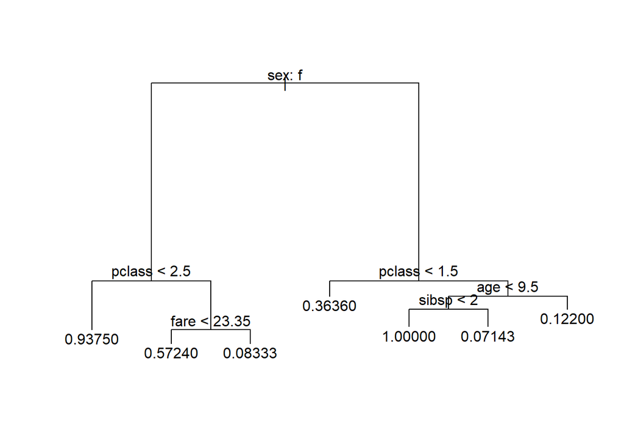

```r
plot(tree.data2, main = "Titanic Decision Tree")
text(tree.data2, pretty = 1)
```

```r
tree.pred <- predict(tree.data, test, type="class")
with(test, table(tree.pred, survived))
```

```
##          survived
## tree.pred   0   1
##         0 150  29
##         1  26  77
```

## Task 7.

Prune your decision tree learnt in task 5. To do so, use cost complexity pruning and perform cross-validation in order to determine the optimal level of tree complexity. What is the size of the pruned decision tree?

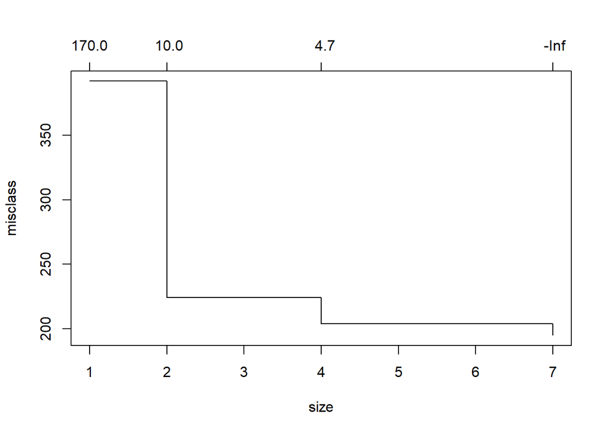

```r
cv.data <- cv.tree(tree.data, FUN = prune.misclass)
plot(cv.data)
```

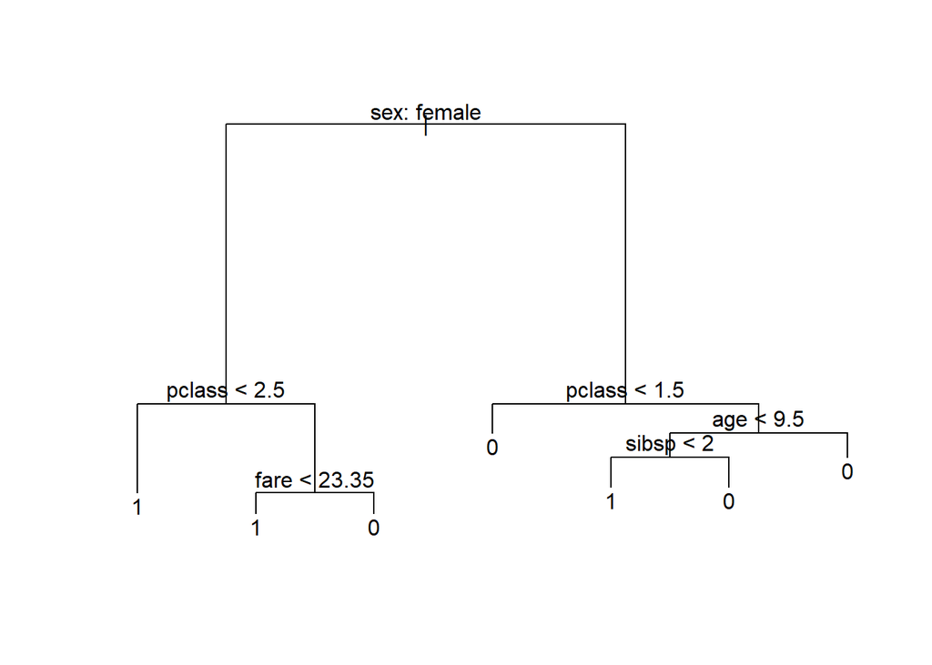

```r
best.size <- cv.data$size[which(cv.data$dev==min(cv.data$dev))]
prune.data <- prune.tree(tree.data, best = best.size)
plot(prune.data)
text(prune.data, pretty = 0)
```

```r
library(pROC)
roc.tree = roc(test$survived, as.numeric(as.character(tree.pred)))
auc.tree = auc(roc.tree)
auc.tree
```

```
## Area under the curve: 0.7893
```